# Machine Learning: Document Classification and Topic Modeling

Alex Hanna

January 21, 2016

« Text Analysis Module

Machine learning can be defined as a set of probabilistic methods that can automatically detect patterns in data and use that information to make predictions in other data. Machine learning methods are at the center of most data science machinery, including those which have to do with text.

We are going to explore two types of machine learning methods in this section: document classification and topic modeling. Document classification is a best used when you know the categories you are trying to predict, while topic modeling better-suited when you do not know these categories. This image from Grimmer and Stewart (2013) is a good visual for where the divisions occur.

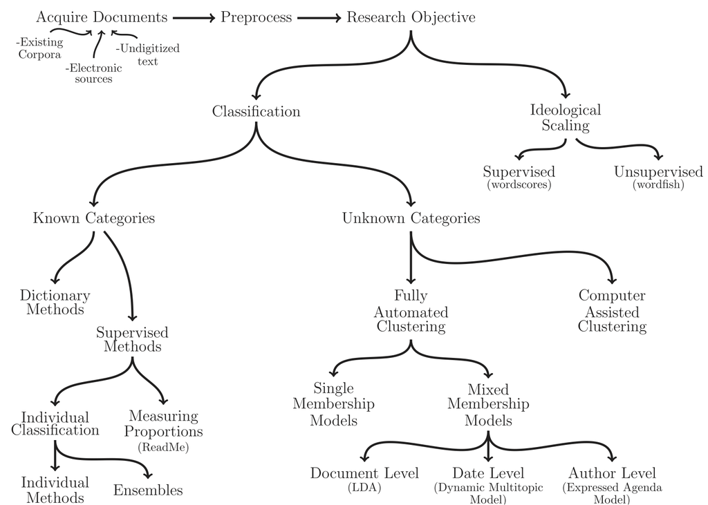

## Document Classification

Document classification is in a class of methods known as “supervised machine learning,” which just means that there are humans “supervising” the process of annotation with known categories. This process involves “training” a classifier on a subset of documents, then using that classifier to classify a “test” set of documents.

First, load the `tm` package which we used in the last section, as well as the `RTextTools` package, which has documentation [here](https://cran.r-project.org/web/packages/RTextTools/RTextTools.pdf). `RTextTools` provides functions for document classification, as well some handy functions which simplifies some of the preprocessing we did with `tm`.

```r
library(tm)
# install.packages("RTextTools")
library(RTextTools)

df.tweets <- read.csv("bullying.csv", stringsAsFactors = FALSE)
dtm       <- create_matrix(df.tweets$text, language="english", stemWords = TRUE, weighting = weightTfIdf, removePunctuation = FALSE)
dtm
```

```
## <<DocumentTermMatrix (documents: 5022, terms: 14769)>>
## Non-/sparse entries: 45657/74124261
## Sparsity           : 100%
## Maximal term length: 104
## Weighting          : term frequency - inverse document frequency (normalized) (tf-idf)
```

We will replace “y” with “1” and “n” with “0” for the `bullying_traces` column, which indicates whether that particular tweet refers to potential bullying. Convert the column to a `numeric` type.

```r
df.tweets$bullying_traces[df.tweets$bullying_traces == 'y'] <- 1
df.tweets$bullying_traces[df.tweets$bullying_traces == 'n'] <- 0
df.tweets$bullying_traces <- as.numeric(df.tweets$bullying_traces)
```

We will use 90% of the data for the training set and 10% for the test set. Then, we will create a container which can be used with `RTextTools` models.

```r
training_break <- as.integer(0.9*nrow(df.tweets))
container      <- create_container(dtm, t(df.tweets$bullying_traces), trainSize=1:training_break, testSize=training_break:nrow(df.tweets), virgin=FALSE)
```

Now we can train and cross-validate a supervised learning model. We can see which ones are available with print_algorithms().

```r
print_algorithms()
```

```
## [1] "BAGGING"  "BOOSTING" "GLMNET"   "MAXENT"   "NNET"     "RF"
## [7] "SLDA"     "SVM"      "TREE"
```

Ideally, we would play around with multiple classifiers and find the one which works the best for the task. But for this workshop, we will choose the [Support Vector Machine](https://en.wikipedia.org/wiki/Support_vector_machine) (SVM).

Cross-validation is a process of breaking up the training set into *k* folds, using *k - 1* folds as a training set and testing it against the last fold. We will use 3 folds.

Accuracy is a measure defined as true positives + true negatives / the total population of items. It is equivalent to the proportion of correctly predict cases, and considered here a rough metric of model performance.

```r
cv.svm <- cross_validate(container, 3, algorithm = 'SVM', kernel = 'linear')
```

```
## Fold 1 Out of Sample Accuracy = 0.7982036
## Fold 2 Out of Sample Accuracy = 0.8041056
## Fold 3 Out of Sample Accuracy = 0.8070388
```

```r
cv.svm$meanAccuracy
```

```
## [1] 0.803116
```

How good is this result? One way to think about is to compare with different random benchmarks. Since we have two categories, one benchmark would be 50%. Another one would be always choosing the modal category.

```r
prop.table(table(df.tweets$bullying_traces))
```

```
##
##         0         1
## 0.7369574 0.2630426
```

The metrics of [precision, recall, and F-score](https://en.wikipedia.org/wiki/Precision_and_recall) are somewhat more descriptive than accuracy. *Precision* is the proportion of classified documents which are selected (% correct positives), while *recall* is the number of relevant documents which have been selected (% true values correctly predicted).

In the supervised learning example, a high precision indicates that the classifier can correctly classify documents without many false hits, while a high recall indicates that it can retrieve a high number of correctly classifed documents. *F1-score* is the harmonic mean of the two metrics.

Now we can train the model, apply the trained model to our test set, and create analytics.

```r
models    <- train_model(container, algorithms = c("SVM"))
results   <- classify_model(container, models)
analytics <- create_analytics(container, results)
```

Once we have trained the model and applied it, we can produce precision, recall, and F-score measures with `create_analytics`. We can also see which label the model applied, the correct label, and the confidence score which was assigned to it.

```r
# performance
analytics@algorithm_summary
```

```
##   SVM_PRECISION SVM_RECALL SVM_FSCORE
## 0          0.85       0.91       0.88
## 1          0.65       0.50       0.57
```

```r
apply(analytics@algorithm_summary, 2, mean)
```

```
## SVM_PRECISION    SVM_RECALL    SVM_FSCORE
##         0.750         0.705         0.725
```

```r
# predicted labels in training dataset
head(analytics@document_summary[1:3])
```

```
##   SVM_LABEL  SVM_PROB MANUAL_CODE
## 1         0 0.7744603           0
## 2         0 0.7620393           0
## 3         1 0.5868253           1
## 4         1 0.6866217           0
## 5         0 0.6832319           0
## 6         0 0.8724630           0
```

## Topic Modeling

While supervised learning is used when we know the categories we want to produce, unsupervised learning (including topic modeling) is used when we do not know the categories. In topic modeling, documents are not assumed to belong to one topic or category, but simultaneously belong to several topics. The topic distributions also vary over documents.

The workhorse function for the topic model is `LDA`, which stands for Latent Dirichlet Allocation, the technical name for this particular kind of model.

We will leave the bullying dataset for the challenge, and now use a different dataset that contains the lead paragraph of around 5,000 articles about the economy published in the New York Times between 1980 and 2014. As before, we will preprocess the text using the standard set of techniques.

The number of topics in a topic model is somewhat arbitrary, so you need to play with the number of topics to see if you get anything more meaningful. We start here with 20 topics.

```r
# install.packages("topicmodels")
library(topicmodels)
# reading data and preparing corpus object
nyt <- read.csv("nytimes.csv", stringsAsFactors = FALSE)
corpus <- VCorpus(VectorSource(nyt$lead_paragraph)) # convert to corpus object
corpus <- tm_map(corpus, content_transformer(tolower)) # to lowercase
corpus <- tm_map(corpus, removePunctuation) # remove punctuation
corpus <- tm_map(corpus, removeNumbers) # remove digits
corpus <- tm_map(corpus, removeWords, stopwords("english")) # remove stopwords
# construct DTM only with words 3+ characters long that appears 10+ times
dtm <- DocumentTermMatrix(corpus, control=list(minWordLength=3, bounds=list(10, Inf)))

# estimate LDA with K topics
K <- 20
lda      <- LDA(dtm, k = K, method = "Gibbs",
                control = list(verbose=25L, seed = 123, burnin = 100, iter = 100))
```

```
## K = 20; V = 20781; M = 5000
## Sampling 200 iterations!
## Iteration 25 ...
## Iteration 50 ...
## Iteration 75 ...
## Iteration 100 ...
## Iteration 125 ...
## Iteration 150 ...
## Iteration 175 ...
## Iteration 200 ...
## Gibbs sampling completed!
```

We can use `get_terms` to the top `n` terms from the topic model, and `get_topics` to predict the top `k` topic for each document. This will help us interpret the results of the model.

```r
terms <- get_terms(lda, 15)
terms[,1:4]
```

```
##       Topic 1         Topic 2      Topic 3          Topic 4
##  [1,] "sales"         "percent"    "economic"       "market"
##  [2,] "index"         "department" "budget"         "stock"
##  [3,] "consumer"      "rose"       "administration" "yesterday"
##  [4,] "may"           "today"      "spending"       "investors"
##  [5,] "level"         "reported"   "reagan"         "markets"
##  [6,] "since"         "said"       "billion"        "day"
##  [7,] "manufacturing" "month"      "deficit"        "stocks"
##  [8,] "yesterday"     "commerce"   "program"        "week"
##  [9,] "month"         "decline"    "fiscal"         "average"
## [10,] "report"        "increase"   "today"          "industrial"
## [11,] "confidence"    "quarter"    "government"     "points"
## [12,] "june"          "fell"       "president"      "bond"
## [13,] "july"          "months"     "military"       "prices"
## [14,] "production"    "goods"      "officials"      "wall"
## [15,] "thursday"      "orders"     "deficits"       "record"
```

```r
topics <- get_topics(lda, 1)
head(topics)
```

```
##  1  2  3  4  5  6
##  6  6 15 16  4 20
```

Let’s take a closer look at some of these topics. To help us interpret the output, we can look at the words associated with each topic and take a random sample of documents highly associated with each topic.

```r
# Topic 4
paste(terms[,4], collapse=", ")
```

```
## [1] "market, stock, yesterday, investors, markets, day, stocks, week, average, industrial, points, bond, prices, wall, record"
```

```r
sample(nyt$lead_paragraph[topics==4], 2)
```

```
## [1] "Shares finished higher on Thursday as investors set aside some concerns about downbeat economic reports and focused on strong profits from the Oracle Corporation. Corporate results and economic news offered investors a mixed picture and kept stocks fluctuating throughout much of the day."
## [2] "Every earnings season can hold nasty surprises for investors. But with the stock market swooning lately over reports of financial turmoil in Asia and every lowering of profit expectations by a major American corporation, some analysts are worrying that the shocks in early 1998 will be partic…
```

```r
# Topic 13
paste(terms[,13], collapse=", ")
```

```
## [1] "federal, rates, interest, reserve, policy, fed, chairman, rate, bank, meeting, greenspan, cut, point, committee, central"
```

```r
sample(nyt$lead_paragraph[topics==13], 2)
```

```
## [1] "''If you build in wages and other benefits based upon an exaggerated Consumer Price Index, you ratchet up inflation at a time when productivity is not rising,And that is a problem.'' -Paul A. Volcker, chairman of the Federal Reserve Board. (D2:6.)"
## [2] "In another setback for the struggling economic recovery and President Bush's re-election campaign, consumer confidence dropped sharply in July, the Conference Board reported yesterday. The business group's widely followed confidence index fell 16 percent, erasing nearly half of its gain sinc…
```

```r
# Topic 14
paste(terms[,13], collapse=", ")
```

```
## [1] "federal, rates, interest, reserve, policy, fed, chairman, rate, bank, meeting, greenspan, cut, point, committee, central"
```

```r
sample(nyt$lead_paragraph[topics==13], 2)
```

```
## [1] "To the Editor: Re ''Federal Reserve Cuts Its Key Rate by Quarter-Point'' (front page, Aug. 22): The Fed continues to cut the prime rate, making it easier for companies to borrow from banks to enable them to grow, thereby creating a vast increase in American employment, thus spurring the econ…
## [2] "After rising unexpectedly in the beginning of the year, inflation seemed to have abated in May, but the Federal Reserve remains haunted by its specter. Another inflationary spike this year strikes most economists as unlikely in an economy that remains subdued. But the Fed's policy makers say…
```

```r
# Topic 19
paste(terms[,19], collapse=", ")
```

```
## [1] "economy, economic, growth, recession, recovery, economists, recent, strong, months, nations, second, expansion, evidence, signs, still"
```

```r
sample(nyt$lead_paragraph[topics==19], 2)
```

```
## [1] "Wages are rising as the economy across most of the nation continues to grow at a moderate pace, but there is little evidence yet of inflation taking root, the Federal Reserve Board reported today. The report, based on a survey of businesses by the 12 regional Federal Reserve Banks, was the l…
## [2] "Yesterday's good news on the job front, on top of strong growth in the last half of 2003, may finally signal that President Bush's economic recovery is on solid ground. There is still plenty to worry about. Unused production capacity continues to drag down business profits, and job growth, w…
```

You will that often some topics do not make much sense. They just capture the remaining cluster of words, and often correspond to stopwords. For example,

```r
# Topic 10
paste(terms[,10], collapse=", ")
```

```
## [1] "will, year, many, time, less, may, say, americans, next, likely, still, now, whether, first, housing"
```

```r
sample(nyt$lead_paragraph[topics==10], 2)
```

```
## [1] "ALMOST every day, a few letters arrive, saying that a group in some city or town is about to have a ''tea party.'' The gist, in case you haven't received any of these invitations, is that President Obama's taxing and spending plans are far too lavish. The United States will be burdened with …
## [2] "To the Editor: Your Aug. 22 Week in Review article ''Who You Gonna Call After the Next Bust?'' discusses the next recession with clarity. However, it is not, as you suggest, a foregone conclusion that foreign investors will flee the United States if and when the Federal Reserve lowers intere…
```

```r
# Topic 18
paste(terms[,18], collapse=", ")
```

```
## [1] "just, can, people, one, way, get, going, like, think, much, right, things, dont, now, question"
```

```r
sample(nyt$lead_paragraph[topics==18], 2)
```

```
## [1] "Words like ''modest,'' ''moderate'' and ''somewhat faster'' do not typically describe the type of economy that sends Wall Street on a tear. But that is exactly what happened yesterday when the Federal Reserve released its regular snapshot of economic conditions in the United States. The repo…
## [2] "''The point is, ladies and gentlemen, greed is good. Greed works, greed is right. . . . and greed, mark my words, will save not only Teldar Paper but the other malfunctioning corporation called the U.S.A.'' Gordon Gekko, the corporate raider who gave that speech in the 1987 movie ''Wall Stre…
```

In the case of date with timestamps, looking at the evolution of certain topics over time can also help interpret their meaning. Let’s look for example at Topic 7, which appears to be related to inflation.

```r
# Topic 7
paste(terms[,7], collapse=", ")
```

```
## [1] "prices, year, percent, inflation, rate, price, annual, oil, ago, rising, last, energy, consumer, corporate, higher"
```

```r
sample(nyt$lead_paragraph[topics==7], 2)
```

```
## [1] "Lawyers, engineers, secretaries and other white-collar workers averaged smaller raises last year than in the previous two years, the Government has reported. However, the prices Americans paid for most items also rose less last year, so the workers' standards of living were not necessarily h…
## [2] "Prices for beef, milk, eggs and some other grocery items have been dropping for several months, providing relief for consumers who suffered through the steep increases of a year ago. But prices are likely to start edging upward again as the economy recovers, according to a new federal report…
```

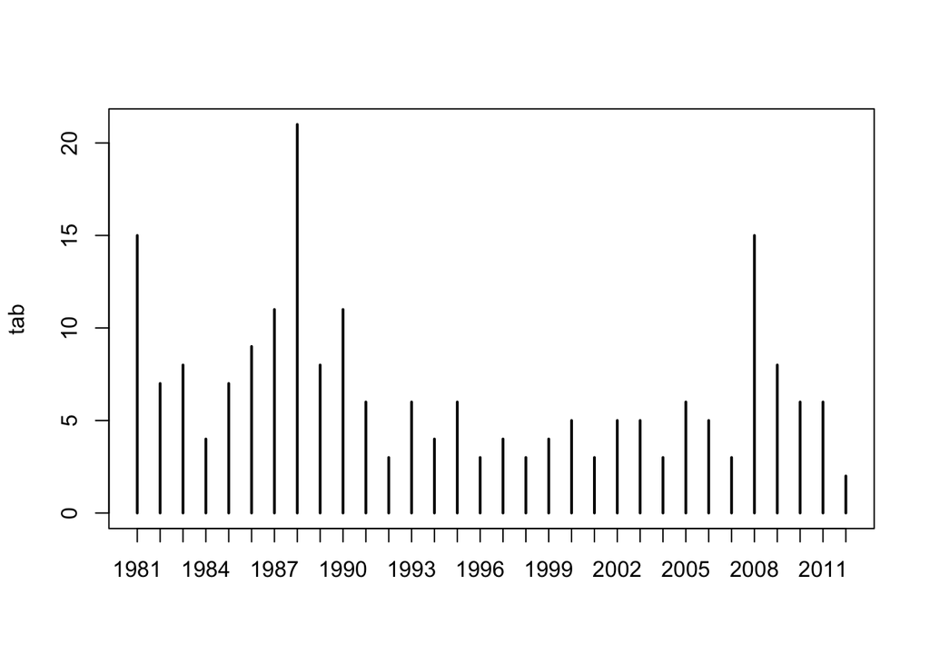

```r
# add predicted topic to dataset
nyt$pred_topic <- topics
nyt$year <- substr(nyt$datetime, 1, 4) # extract year
 # frequency table with articles about inflation, per year
tab <- table(nyt$year[nyt$pred_topic==7])
plot(tab)
```

But we can actually do better than this. LDA is a probabilistic model, which means that for each document, it actually computes a distribution over topics. In other words, each document is considered to be **about a mixture of topics**.

```r
round(lda@gamma[1:5, 1:5], 2)
```

```
##      [,1] [,2] [,3] [,4] [,5]
## [1,] 0.04 0.03 0.03 0.04 0.04
## [2,] 0.04 0.03 0.03 0.04 0.03
## [3,] 0.03 0.03 0.05 0.03 0.06
## [4,] 0.03 0.04 0.04 0.03 0.08
## [5,] 0.05 0.07 0.03 0.12 0.03
```

```r
round(lda@gamma[3,], 2)
```

```
##  [1] 0.03 0.03 0.05 0.03 0.06 0.02 0.03 0.03 0.02 0.02 0.04 0.08 0.15 0.04
## [15] 0.17 0.03 0.04 0.08 0.04 0.02
```

So we can actually take the information in the matrix and aggregate it to compute the average probability that an article each year is about a particular topic. Let’s now choose Topic 11, which appears to be related to the financial crisis.

```r
# Topic 11
paste(terms[,11], collapse=", ")
```

```
## [1] "financial, news, crisis, economy, time, street, debt, credit, wall, big, much, banks, good, enough, markets"
```

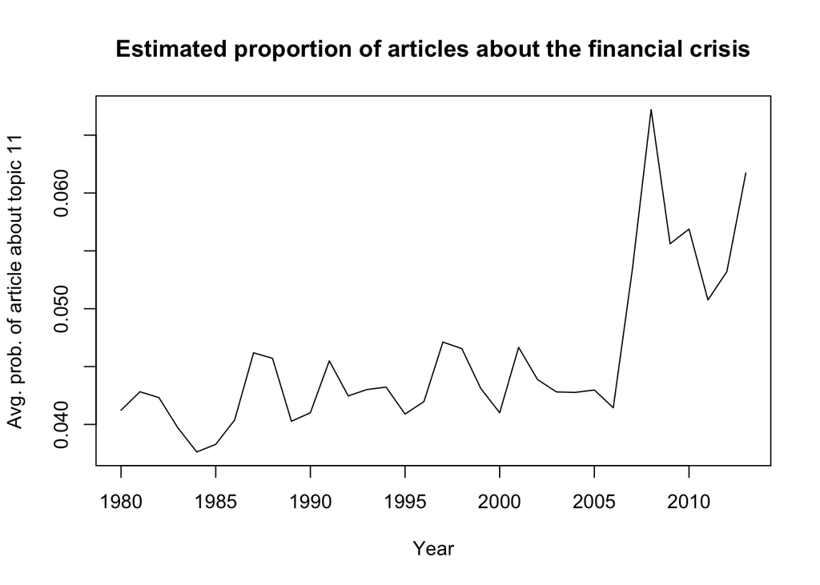

```r
# add probability to df
nyt$prob_topic_11 <- lda@gamma[,11]
# now aggregate at the year level
agg <- aggregate(nyt$prob_topic_11, by=list(year=nyt$year), FUN=mean)
# and plot it
plot(agg$year, agg$x, type="l", xlab="Year", ylab="Avg. prob. of article about topic 11",
     main="Estimated proportion of articles about the financial crisis")
```

Given the peak of this probability in 2008, it does seem this topic is capturing articles about the financial crisis.